# Expected credit loss - explanatory data analysis

Eligijus Bujokas

12/19/2020

# Overview

This document is used to explore the data of the company called “LendingClub”. It is an American company that provides short term loans both for individuals and for bussineses.

To know more about the company, visit: https://www.lendingclub.com/

All the files and codes used in this project are stored in the repo: https://github.com/Eligijus112/expected-credit-loss

The data can be found in kaggle: https://www.kaggle.com/denychaen/lending-club-loans-rejects-data

# Reading the data

```r
# Using fread to read the data
d <- fread('data/Loan_status_2007-2020Q3.gzip')

# Total number of loans in the data set
print(nrow(d))
```

```
## [1] 2925493
```

```r
# Total number of columns
print(ncol(d))
```

```
## [1] 142
```

**addr_state** - The state provided by the borrower in the loan application

**annual_inc** - The self-reported annual income provided by the borrower during registration.

**dti** - debt to income ratio; a ratio calculated using the borrower’s total monthly debt payments on the total debt obligations, excluding mortgage and the requested LC loan, divided by the borrower’s self-reported monthly income.

**emp_length** - Employment length in years. Possible values are between 0 and 10 where 0 means less than one year and 10 means ten or more years.

**earliest_cr_line** - the month at which the earliest credit line was opened for the borrower.

**funded_amnt** - The total amount committed to that loan at that point in time.

**home_ownership** - The home ownership status provided by the borrower during registration or obtained from the credit report. Our values are: RENT, OWN, MORTGAGE, OTHER.

**loan_amnt** - The listed amount of the loan applied for by the borrower. If at some point in time, the credit department reduces the loan amount, then it will be reflected in this value.

**loan_status** - current status of the loan.

**pub_rec** - Number of derogatory public records.

**pub_rec_bankruptcies** - Number of public record bankruptcies

**purpose** - A category provided by the borrower for the loan request.

**issue_d** - The date at which the loan was issued.

**term** - number of payments on the loan. Values can be either 36 or 60.

**int_rate** - interest rate on the loan.

**recoveries** - post charge off gross recovery.

**total_rec_prncp** - principal received to date.

**verification_status** - Indicates if income was verified by LC, not verified, or if the income source was verified.

**delinq_2yrs** - The number of 30+ days past-due incidences of delinquency in the borrower’s credit file for the past 2 years.

```r
# Defining all the columns used in the analysis
cols_to_use = c(
  "addr_state",
  "annual_inc",
  'emp_length',
  'earliest_cr_line',
  'funded_amnt',
  'home_ownership',
  'loan_amnt',
  'loan_status',
  'pub_rec',
  'pub_rec_bankruptcies',
  'purpose',
  'issue_d',
  'term',
  'int_rate',
  'recoveries',
  'total_rec_prncp',
  'dti',
  'verification_status',
  "delinq_2yrs",
  "initial_list_status",
  "hardship_flag",
  "grade"
)

# Subseting the data
d <- d[, ..cols_to_use]

# Printing the top of the data table
head(d)
```

```
##    addr_state annual_inc emp_length earliest_cr_line funded_amnt home_ownership
## 1:         AZ      24000  10+ years         Jan-1985        5000           RENT
## 2:         GA      30000   < 1 year         Apr-1999        2500           RENT
## 3:         IL      12252  10+ years         Nov-2001        2400           RENT
## 4:         CA      49200  10+ years         Feb-1996       10000           RENT
## 5:         OR      80000     1 year         Jan-1996        3000           RENT
## 6:         AZ      36000    3 years         Nov-2004        5000           RENT
##    loan_amnt loan_status pub_rec pub_rec_bankruptcies        purpose  issue_d
## 1:      5000  Fully Paid       0                    0    credit_card Dec-2011
## 2:      2500 Charged Off       0                    0            car Dec-2011
## 3:      2400  Fully Paid       0                    0 small_business Dec-2011
## 4:     10000  Fully Paid       0                    0          other Dec-2011
## 5:      3000  Fully Paid       0                    0          other Dec-2011
## 6:      5000  Fully Paid       0                    0        wedding Dec-2011
##         term int_rate recoveries total_rec_prncp   dti verification_status
## 1: 36 months   10.65%        0.0         5000.00 27.65            Verified
## 2: 60 months   15.27%      122.9          456.46  1.00     Source Verified
## 3: 36 months   15.96%        0.0         2400.00  8.72        Not Verified
## 4: 36 months   13.49%        0.0        10000.00 20.00     Source Verified
## 5: 60 months   12.69%        0.0         3000.00 17.94     Source Verified
## 6: 36 months    7.90%        0.0         5000.00 11.20     Source Verified
##    delinq_2yrs initial_list_status hardship_flag grade
## 1:           0                   f             N     B
## 2:           0                   f             N     C
## 3:           0                   f             N     C
## 4:           0                   f             N     C
## 5:           0                   f             N     B
## 6:           0                   f             N     A
```

# Data cleaning and engineering

Before analyzing the various splits of the data there are some columns that need to be cleaned and engineered.

## Date columns

```r
# Creating the splited columns
d[, c("issue_m", "issue_y"):=tstrsplit(issue_d, "-")]

# Getting the last two digits of issue_y
d[, issue_y:=str_sub(issue_y, -2)]

# Creating the formated column
d[, issue_d_formated:=zoo::as.yearmon(paste(issue_m, issue_y, sep="-"), "%b-%y")]

# Creating the splited columns
d[, c("cr_m", "cr_y"):=tstrsplit(earliest_cr_line, "-")]

# Getting the last two digits of issue_y
d[, cr_y:=str_sub(cr_y, -2)]

# Wrangling the earliest cr column
d[, earliest_cr_line_formated:=zoo::as.yearmon(paste(cr_m, cr_y, sep="-"), "%b-%y")]

# Calculating the difference between the two dates
d[, day_diff:=difftime(issue_d_formated, earliest_cr_line_formated, units='days')]

# Converting to numeric
d[, day_diff:=as.numeric(day_diff)]

# Dropping negative or missing values from the dataframe; these are very old accounts and compise a fraction of percent of the whole data
d <- d[d$day_diff > 0 & !is.na(d$day_diff)]

# Calculating the month diff
d[, month_diff:=round(day_diff/30)]
```

## Historic loan issues

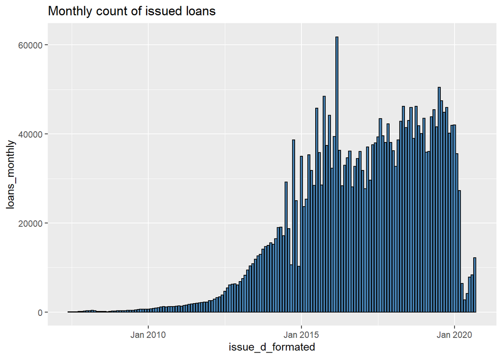

```r
# Aggregating by issue date and sorting
loan_n = d[, .N, by="issue_d_formated"] %>%
  .[order(issue_d_formated)] %>%
  .[, issue_year:=year(issue_d_formated)] %>%
  .[, N_y:=sum(N), by='issue_year'] %>%
  setnames(., c('N', 'N_y'), c('loans_monthly', 'loans_yearly'))

# Ploting the time series
p1 <- ggplot(data=loan_n, aes(x=issue_d_formated, y=loans_monthly)) +
  geom_bar(stat="identity", fill="steelblue", color='black') +
  ggtitle('Monthly count of issued loans')

p1
```

## Creating the Y variable

```r
# Printing out unique loan statuses
print(unique(d$loan_status))
```

```
##  [1] "Fully Paid"
##  [2] "Charged Off"
##  [3] "Does not meet the credit policy. Status:Fully Paid"
##  [4] "Does not meet the credit policy. Status:Charged Off"
##  [5] "Current"
##  [6] "Late (31-120 days)"
##  [7] "In Grace Period"
##  [8] "Late (16-30 days)"
##  [9] "Default"
## [10] "Issued"
```

```r
# Function to encode the good loans as 1 and 0 as bad loans
create_Ypd <- function(x, bad_loans=c('Late (31-120 days)', "Default", "Charged Off", "Does not meet the credit policy. Status:Charged Off")){
  return(ifelse(is.element(x, bad_loans), 'bad', 'good'))
}

# Creating the Y variable
d[, Y:=create_Ypd(loan_status)]

# Saving the variable as factor
d$Y <- as.factor(d$Y)
```

```r
d <- d[issue_d_formated < zoo::as.yearmon('2019-01')]

print(nrow(d))
```

```
## [1] 2255653
```

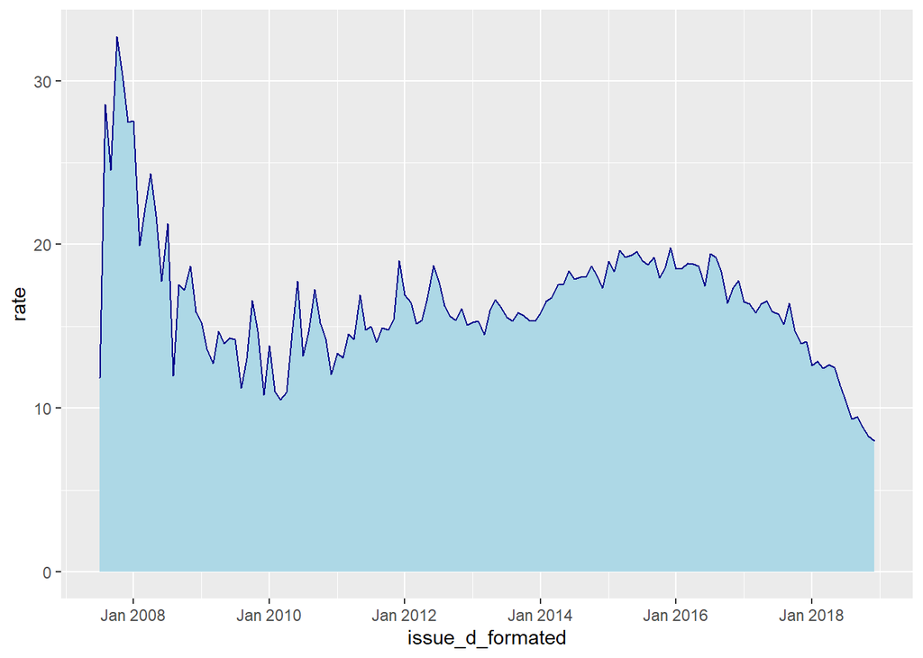

```r
# Visualizing the distribution of Y
bymonth <- d[, .N, by=c("issue_d_formated", "Y")] %>%
  cast(., issue_d_formated ~ Y, value="N") %>%
  data.table(.) %>%
  .[, rate:=bad * 100/(bad + good)]

# Calculating the shares
ggplot(data=bymonth, aes(x=issue_d_formated, y=rate)) + geom_area(color="darkblue", fill="lightblue")
```

Issued loans by grade

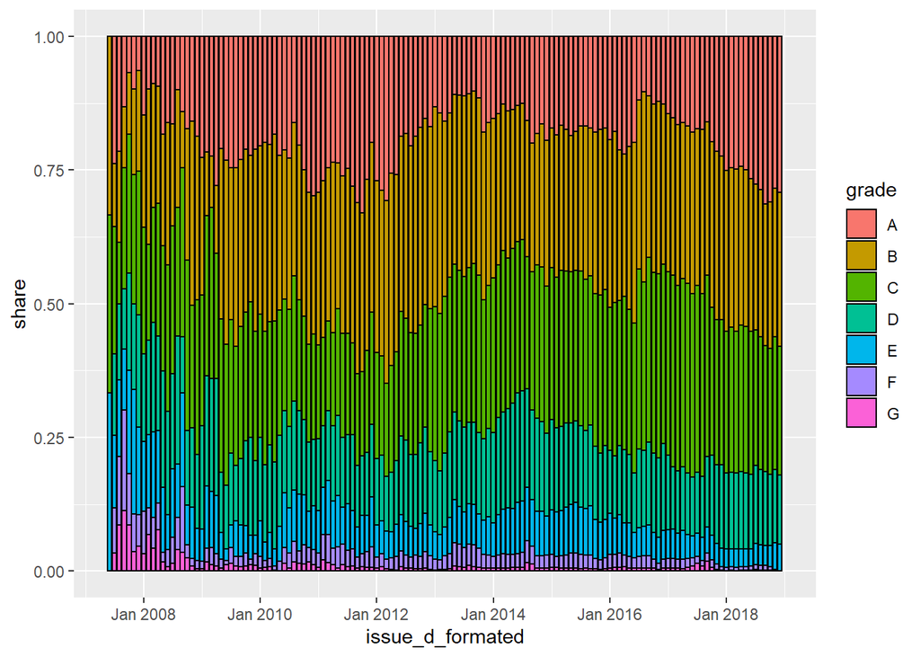

```r
share_by_grade = d[, .("total_issued_grade" = .N), by=c('issue_d_formated', 'grade')]
total_issued = d[, .("total_issued" = .N), by='issue_d_formated']

# Merging the information
merged = merge(share_by_grade, total_issued, all.x=TRUE)

# Calculating the share
merged[, share:=total_issued_grade/total_issued]

ggplot(data=merged, aes(x=issue_d_formated, y=share, fill=grade)) + geom_bar(position="stack", stat="identity", color='black')
```

## Summary statistics of numeric features

```r
# Cleaning the interest rates
d$int_rate <- as.numeric(gsub("%", "", d$int_rate))

summary(d[, c('annual_inc', 'loan_amnt', 'pub_rec', 'int_rate', 'dti', 'month_diff')])
```

```
##    annual_inc          loan_amnt        pub_rec           int_rate
##  Min.   :        0   Min.   :  500   Min.   : 0.0000   Min.   : 5.31
##  1st Qu.:    46000   1st Qu.: 8000   1st Qu.: 0.0000   1st Qu.: 9.49
##  Median :    65000   Median :12900   Median : 0.0000   Median :12.62
##  Mean   :    77982   Mean   :15046   Mean   : 0.1973   Mean   :13.09
##  3rd Qu.:    93000   3rd Qu.:20000   3rd Qu.: 0.0000   3rd Qu.:15.99
##  Max.   :110000000   Max.   :40000   Max.   :86.0000   Max.   :30.99
##
##       dti           month_diff
##  Min.   : -1.00   Min.   :  6.0
##  1st Qu.: 11.90   1st Qu.:137.0
##  Median : 17.84   Median :181.0
##  Mean   : 18.82   Mean   :198.7
##  3rd Qu.: 24.49   3rd Qu.:246.0
##  Max.   :999.00   Max.   :608.0
##  NA's   :1709
```

## Debt to income ratio

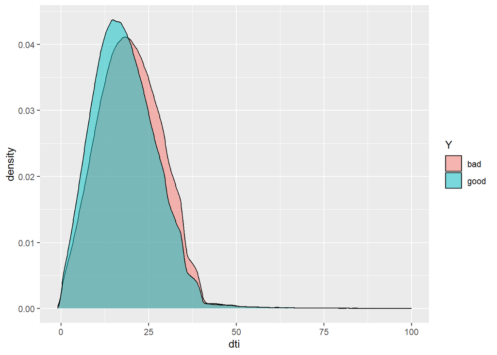

```r
ggplot(data=d[dti<100], aes(x=dti, fill=Y)) + geom_density(alpha=0.5)
```

```r
# Droping the rows with negative dti
d <- d[dti>=0]
```

## Annual income

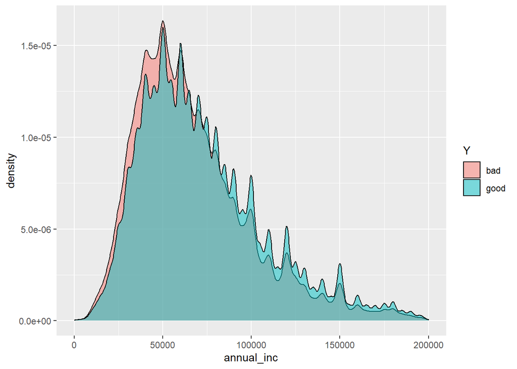

```r
ggplot(data=d[annual_inc < 200000], aes(x=annual_inc, fill=Y)) + geom_density(alpha=0.5)
```

## Loan amount

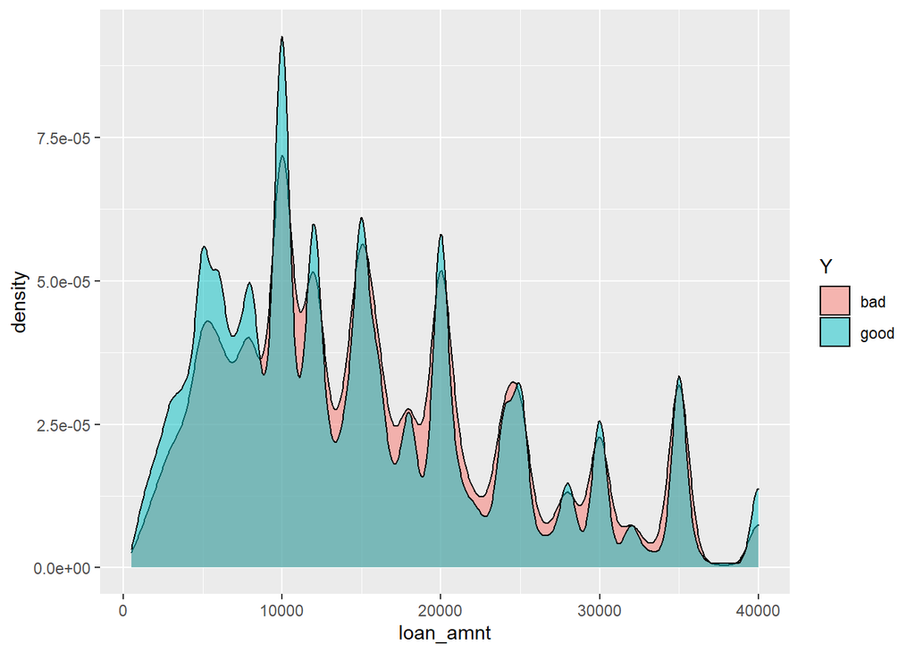

```r
ggplot(data=d, aes(x=loan_amnt, fill=Y)) + geom_density(alpha=0.5)
```

## Interest rate

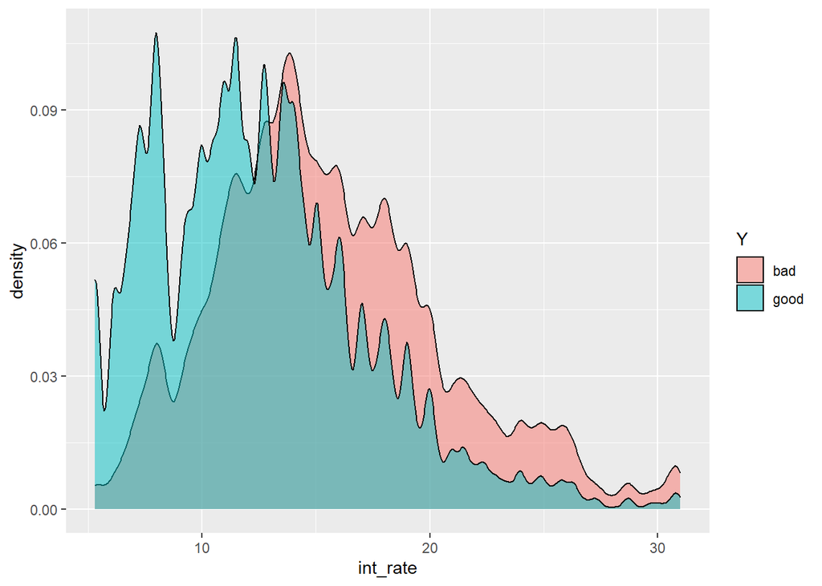

```r
ggplot(data=d, aes(x=int_rate, fill=Y)) + geom_density(alpha=0.5)
```

## Cleaninng the employment length variable

```r
clean_emp_length <- function(x){
  return(ifelse(x=="", "< 1 year", x))
}

d[, emp_length:=clean_emp_length(emp_length)]
```

## Cleaaning the hadsdhip flag variable

```r
clean_hardship <- function(x){
  if(x == ''){
    return('missing')
  } else {
    return(x)
  }
}

d$hardship_flag <- sapply(d$hardship_flag, clean_hardship)
```

# LGD and EAD variables

The data for modeling is all charged off loans.

```r
loan_default_data = d[loan_status %in% c("Charged Off", "Does not meet the credit policy. Status:Charged Off")]
```

## LGD independant variable - recovery rate

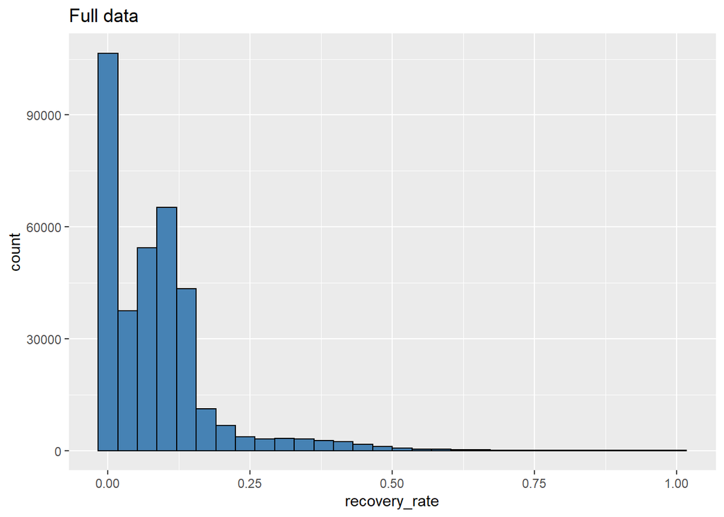

```r
loan_default_data[, recovery_rate:=recoveries/funded_amnt]
loan_default_data[, recovery_rate:=ifelse(recovery_rate>1, 1, recovery_rate)]

# Ploting the recovery rate distribution
p1 <- ggplot(data=loan_default_data, aes(x=recovery_rate)) + geom_histogram(fill='steelblue', color='black') + ggtitle('Full data')

p1
```

## EAD independant variable - credit conversion factor

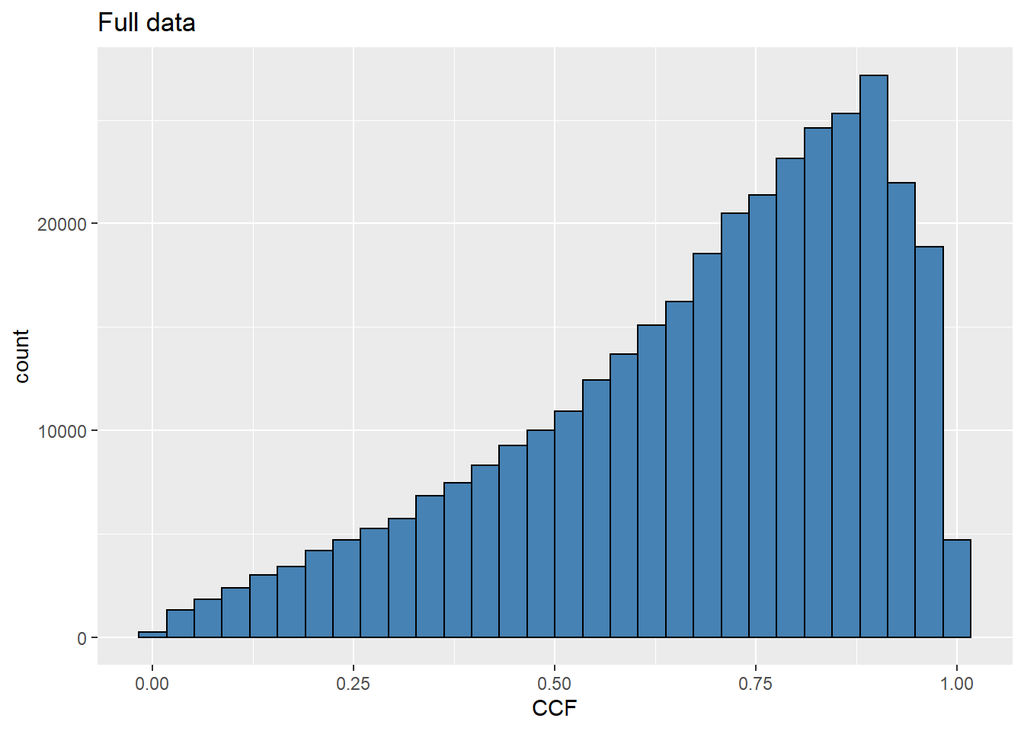

```r
loan_default_data[, CCF:=(funded_amnt - total_rec_prncp)/funded_amnt]

# Ploting the recovery rate distribution
p1 <- ggplot(data=loan_default_data, aes(x=CCF)) + geom_histogram(fill='steelblue', color='black') + ggtitle('Full data')

p1
```

# Creating the datasets for further modeling

## Spliting to train and test sets

```r
train <- d[issue_d_formated < zoo::as.yearmon('2018-01')]
test <- d[issue_d_formated >= zoo::as.yearmon('2018-01')]
```

## Weight of evidence

To infer what categorical feature values are the most influential in determining bad loan from a good loan we can use the weight of evidence (WOE for short) criteria. For a feature $i$ and the feature level $j$ the $WOE_{i, j}$ is calculated with the following formula:

$$WOE_{i, j} = log \left(\dfrac{P(X_{i}=j|Y=1)}{P(X_{i} = j|Y=0)}\right)$$
Lets define a function in R that calculates the WOE statistic for any given feature. Note, that the dependent variable needs to be called **Y**.

```r
woe <- function(feature, data){
  # Grouping by the feature and getting the total number of observations in each level
  woeTable <- data[, .N, by=c("Y", feature)] %>%
    # Seting the names
    setnames(., c('Y', 'feature', 'N')) %>%
    # Casting so that Y is in the columns
    cast(., feature ~ Y, value="N") %>%
    # Converting back to data.table
    data.table(.) %>%
    # Filling the missing values with 0
    setnafill(., fill=0, cols=c('good', 'bad')) %>%
    # Getting the proportions of good and bad borrowers in each level of the variable
    .[, c('prop_good', 'prop_bad') := list(good/sum(good), bad/sum(bad))] %>%
    # Calculating the WOE statistic
    .[, woe:=log(prop_good/prop_bad)] %>%
    # Sorting by the woe stat
    .[order(woe, decreasing=TRUE)]

  return(woeTable)
}

# Example of the function output:
woeResult = woe('purpose', train)
print(woeResult)
```

```
##                feature    bad   good    prop_good     prop_bad         woe
##  1:            wedding    291   2059 0.0014152049 0.0009517891  0.39668612
##  2:                car   2422  16573 0.0113910591 0.0079217636  0.36321490
##  3:        credit_card  57335 330731 0.2273201215 0.1875286191  0.19242778
##  4:   home_improvement  17964  99382 0.0683078645 0.0587558056  0.15063494
##  5:     major_purchase   6231  32518 0.0223504773 0.0203800615  0.09229063
##  6:           vacation   1972  10028 0.0068925083 0.0064499248  0.06636661
##  7:              other  18409  85692 0.0588983671 0.0602112906 -0.02204652
##  8:            medical   3746  17031 0.0117058546 0.0122522405 -0.04561971
##  9: debt_consolidation 187832 827853 0.5690051570 0.6143520638 -0.07667866
## 10:              house   1698   6995 0.0048078476 0.0055537385 -0.14422180
## 11:             moving   2446   9810 0.0067426712 0.0080002617 -0.17101808
## 12:   renewable_energy    238    929 0.0006385262 0.0007784392 -0.19812825
## 13:        educational     88    336 0.0002309416 0.0002878263 -0.22019197
## 14:     small_business   5068  14976 0.0102933990 0.0165761758 -0.47646366
```

```r
# Defining a function to plot the woe
plotWoe <- function(ft, woeData){
  p <- ggplot(woeData, aes(x=reorder(feature, woe), y=woe)) +
            geom_bar(stat="identity", fill="steelblue", color='black') +
            ggtitle(ft) +
            labs(x='Feature value') +
            coord_flip()
   return(p)
}
```

## Iterating through all categorical features

The initial weight of evidence plots:

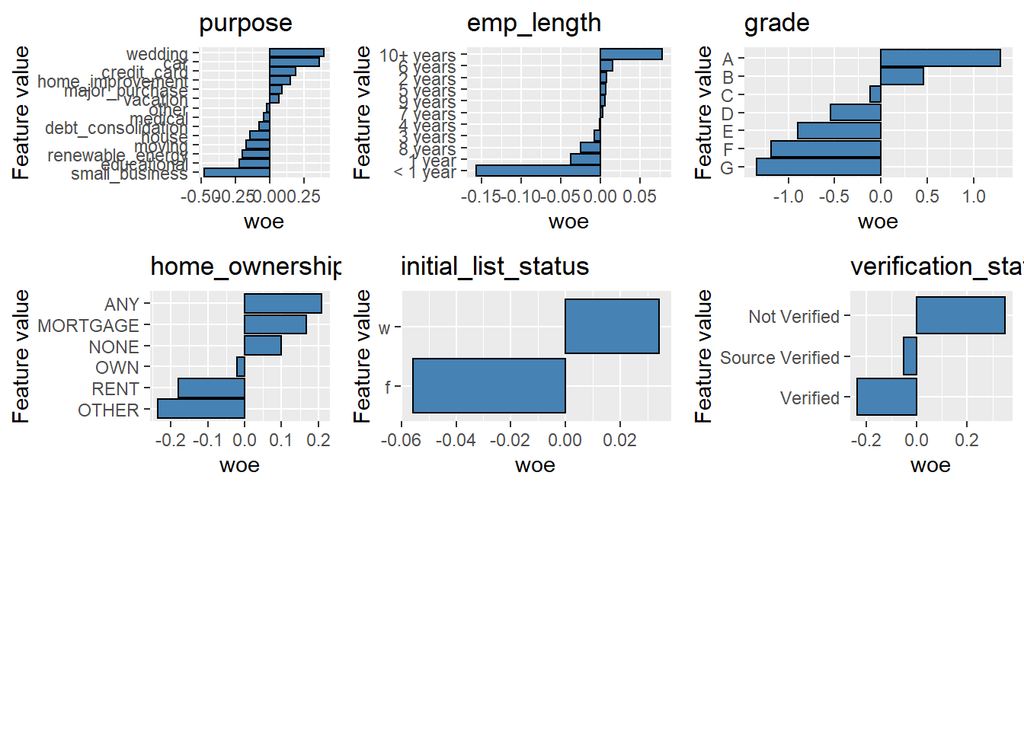

```r
cat_vars <- c("purpose", "emp_length", "grade", "home_ownership", 'initial_list_status', 'verification_status')
plots <- list()

for(cat_var in cat_vars){
  woeStat <- woe(cat_var, train)
  plots[[cat_var]] <- plotWoe(cat_var, woeStat)
}

grid.arrange(plots$purpose, plots$emp_length, plots$grade, plots$home_ownership, plots$initial_list_status, plots$verification_status, ncol = 3, nrow=3)
```

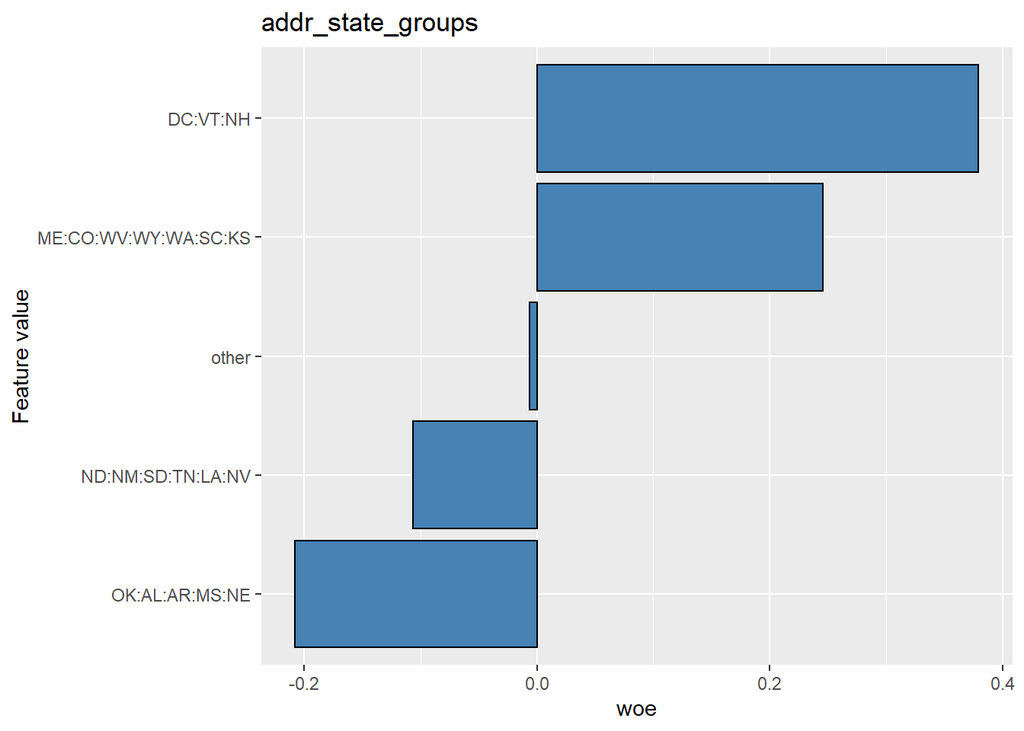

```r
adj_addr_state <- function(x){
  if (is.element(x, c('DC', 'VT', 'NH'))){
    return("DC:VT:NH")
  } else if (is.element(x, c('ME', 'CO', 'WV', 'WY', 'WA', 'SC', 'KS'))){
    return("ME:CO:WV:WY:WA:SC:KS")
  } else if (is.element(x, c('ND', 'NM', 'SD', 'TN', 'LA', 'NV'))){
    return("ND:NM:SD:TN:LA:NV")
  } else if (is.element(x, c("OK", 'AL', 'AR', 'MS', 'NE'))){
    return('OK:AL:AR:MS:NE')
  } else {
    return("other")
  }
}

train$addr_state_groups <- sapply(train$addr_state, adj_addr_state)

woeStat <- woe('addr_state_groups', train)
p <- plotWoe('addr_state_groups', woeStat)
p
```

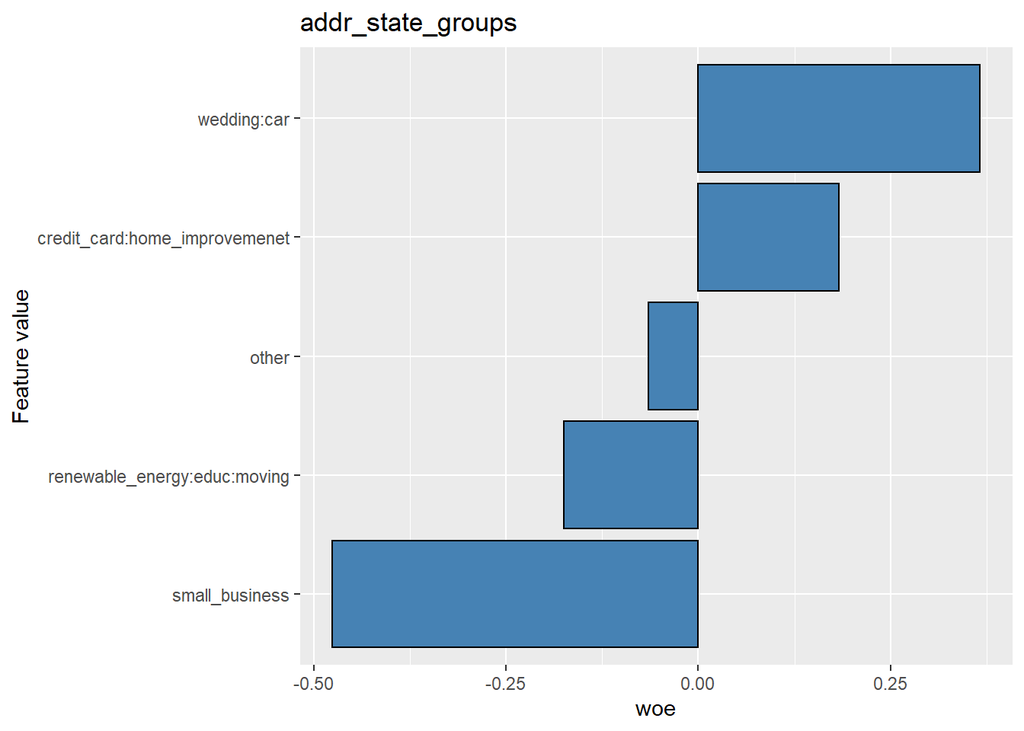

```r
adj_purpose <- function(x){
  if (is.element(x, c('wedding', 'car'))){
    return("wedding:car")
  } else if (is.element(x, c('credit_card', 'home_improvement'))){
    return("credit_card:home_improvemenet")
  } else if (is.element(x, c('small_business'))){
    return("small_business")
  } else if (is.element(x, c('renewable_energy', "educational", "moving"))){
    return('renewable_energy:educ:moving')
  } else {
    return("other")
  }
}

train$purpose_groups <- sapply(train$purpose, adj_purpose)

woeStat <- woe('purpose_groups', train)
p <- plotWoe('addr_state_groups', woeStat)
p
```

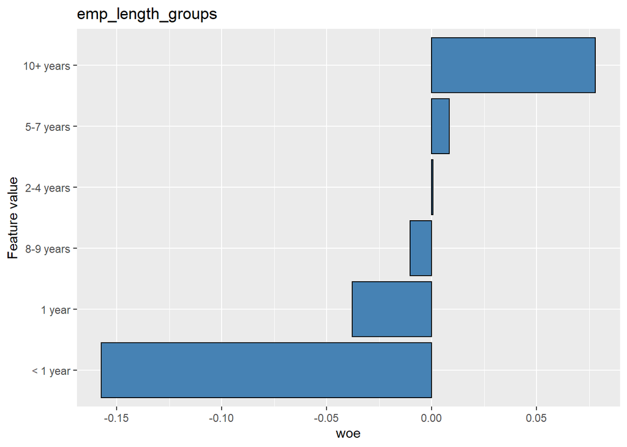

```r
adj_emp_length <- function(x){
  if(is.element(x, ("< 1 year"))){
    return("< 1 year")
  } else if (x=='1 year') {
    return ('1 year')
  } else if (is.element(x, c('2 years', '3 years', '4 years'))){
    return ('2-4 years')
  } else if (is.element(x, c('5 years', '6 years', '7 years')))(
    return('5-7 years')
  ) else if (is.element(x, c('8 years', '9 years'))){
    return('8-9 years')
  } else {
    return('10+ years')
  }
}

train$emp_length_groups <- sapply(train$emp_length, adj_emp_length)

woeStat <- woe('emp_length_groups', train)
p <- plotWoe('emp_length_groups', woeStat)
p
```

## Annual income

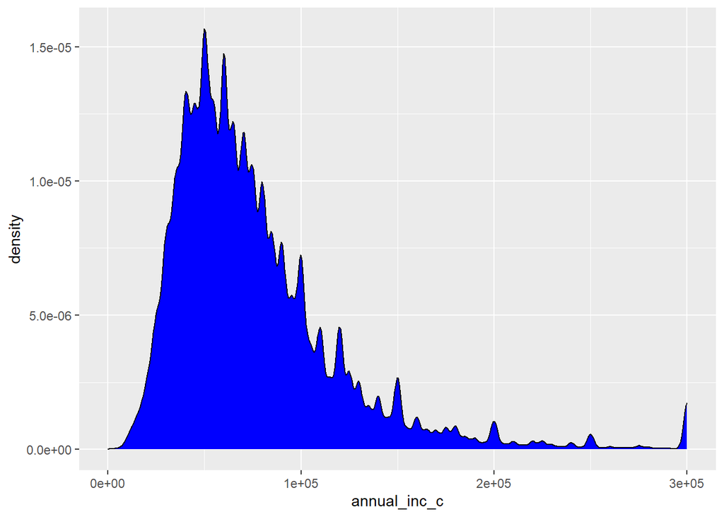

```r
capvalues <- function(x, cap){
  return(min(c(x, cap)))
}

plotWoeNumeric <- function(ft, woeData){
  p <- ggplot(woeData, aes(x=feature, y=woe)) +
            geom_bar(stat="identity", fill="steelblue", color='black') +
            ggtitle(ft) +
            labs(x='Feature value') +
            coord_flip()
   return(p)
}

# Droping the outliers
train$annual_inc_c <- sapply(train$annual_inc, capvalues, cap=300000)

# Ploting the distribution
ggplot(data=train, aes(x=annual_inc_c)) + geom_density(fill='blue')
```

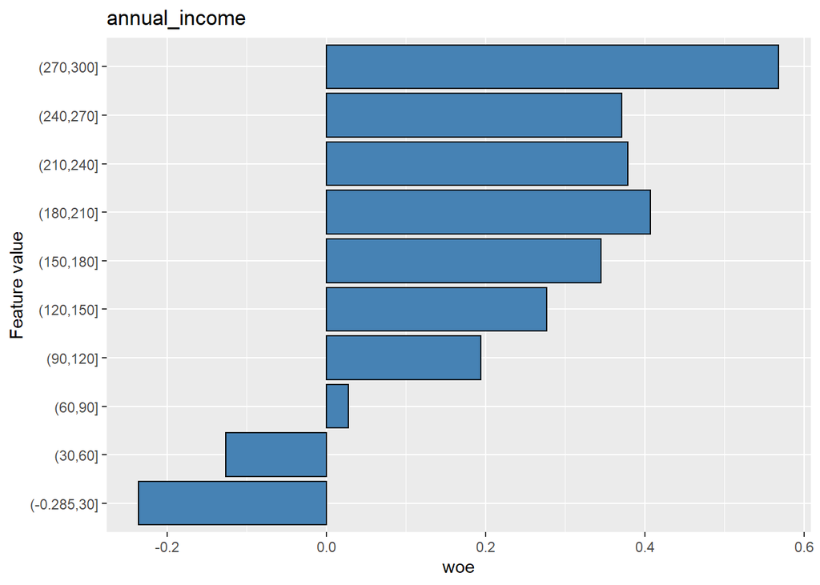

```r
# Cutting the annual income into 10 equal sized partitions
train$annual_inc_groups = cut(train$annual_inc_c / 1000, 10)

woedf <- woe('annual_inc_groups', train)
plotWoeNumeric('annual_income', woedf)
```

Defining a function for annual income split.

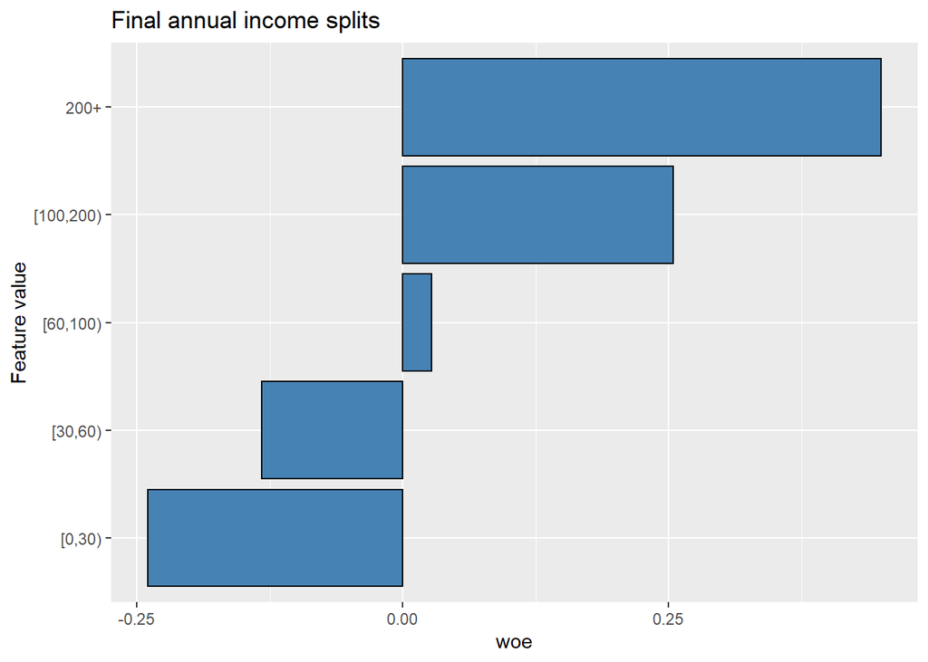

```r
adj_income <- function(x){
  if(x < 30000){
    return("[0,30)")
  } else if (x < 60000){
    return("[30,60)")
  } else if (x < 100000){
    return("[60,100)")
  } else if (x < 200000){
    return("[100,200)")
  } else {
    return("200+")
  }
}

train$annual_inc_groups <- sapply(train$annual_inc, adj_income)

woedf <- woe('annual_inc_groups', train)
plotWoe('Final annual income splits', woedf)
```

## Loan amount

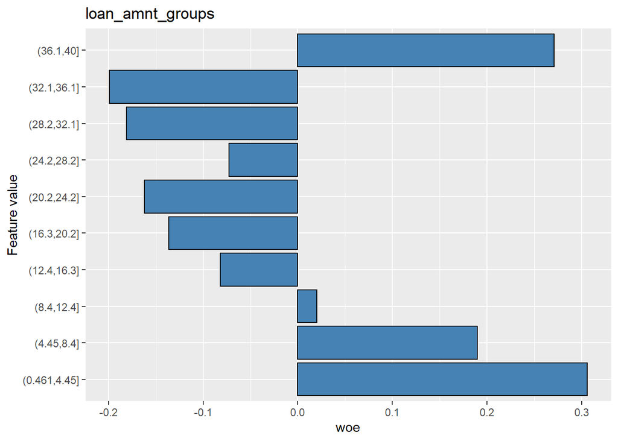

```r
# Cutting the annual income into 10 equal sized partitions
train$loan_amnt_groups = cut(train$loan_amnt/1000, 10)

woedf <- woe('loan_amnt_groups', train)
plotWoeNumeric('loan_amnt_groups ', woedf)
```

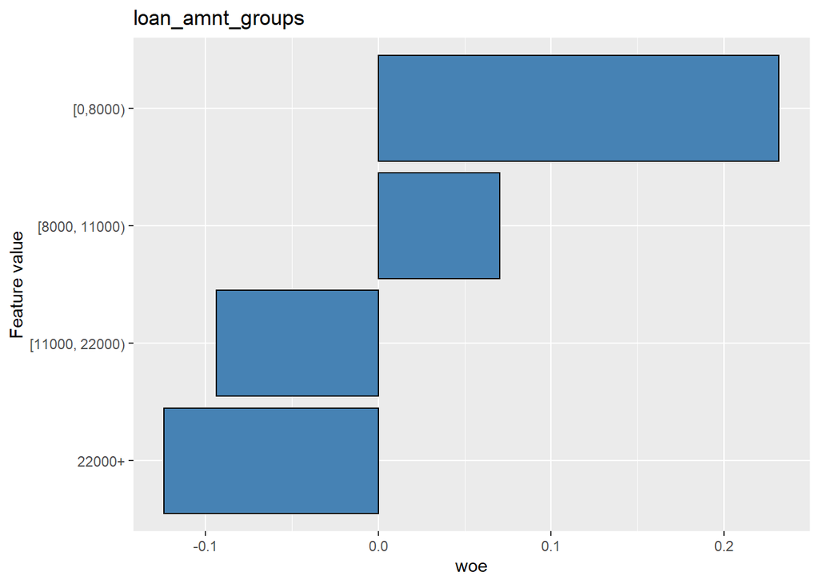

```r
adj_loan_amnt <- function(x){
  if (x < 8000) {
    return("[0,8000)")
  } else if(x < 11000){
    return("[8000, 11000)")
  } else if(x < 22000){
    return("[11000, 22000)")
  } else {
    return("22000+")
  }
}

train$loan_amnt_groups = sapply(train$loan_amnt, adj_loan_amnt)
woedf <- woe('loan_amnt_groups', train)
plotWoe('loan_amnt_groups', woedf)
```

## Interest rate

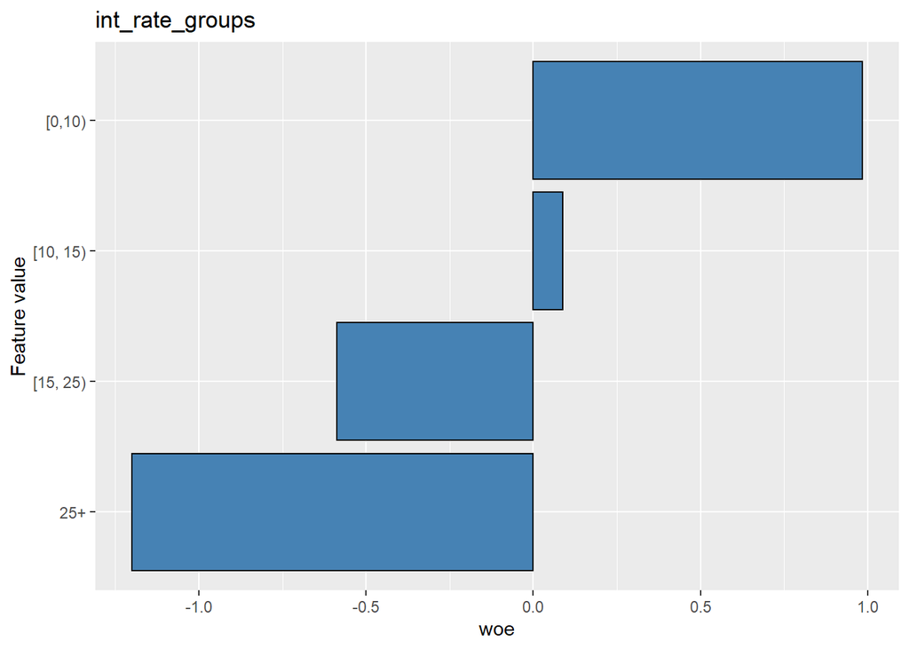

```r
adj_int_rate <- function(x){
  if (x < 10) {
    return("[0,10)")
  } else if(x < 15){
    return("[10, 15)")
  } else if(x < 25){
    return("[15, 25)")
  } else {
    return("25+")
  }
}

train$int_rate_groups = sapply(train$int_rate, adj_int_rate)
woedf <- woe('int_rate_groups', train)
plotWoe('int_rate_groups', woedf)
```

## Past 2 year delinquencies

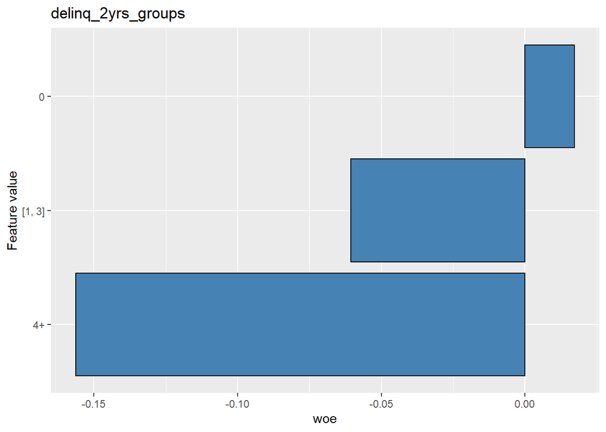

```r
adj_delinq_2yrs <- function(x){
  if(x == 0){
    return('0')
  } else if (x < 4){
    return('[1, 3]')
  } else {
    return('4+')
  }
}

train$delinq_2yrs_groups <- sapply(train$delinq_2yrs, adj_delinq_2yrs)

woedf <- woe('delinq_2yrs_groups', train)
plotWoe('delinq_2yrs_groups', woedf)
```

## DTI

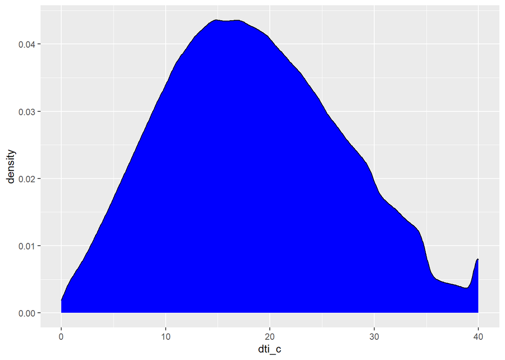

```r
# Droping the outliers
train$dti_c <- sapply(train$dti, capvalues, cap=40)

# Ploting the distribution
ggplot(data=train, aes(x=dti_c)) + geom_density(fill='blue')
```

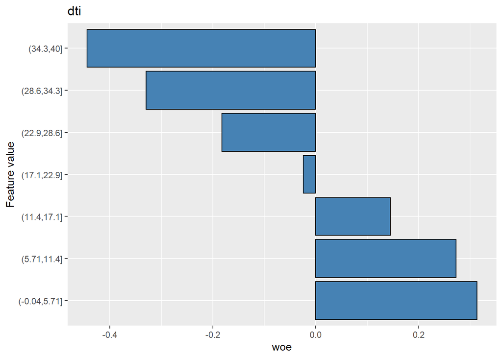

```r
# Cutting the annual income into 10 equal sized partitions
train$dti_groups = cut(train$dti_c, 7)

woedf <- woe('dti_groups', train)
plotWoeNumeric('dti', woedf)
```

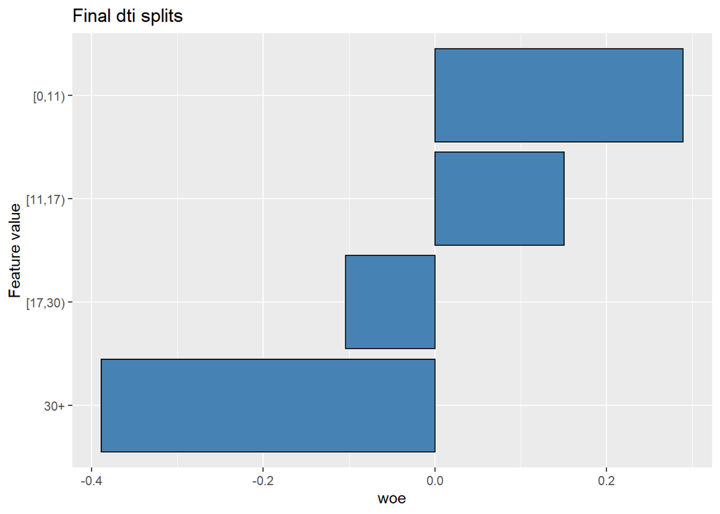

```r
adj_dti <- function(x){
  if(x < 11){
    return("[0,11)")
  } else if (x < 17){
    return("[11,17)")
  } else if (x < 30){
    return("[17,30)")
  } else {
    return("30+")
  }
}

train$dti_groups <- sapply(train$dti, adj_dti)

woedf <- woe('dti_groups', train)
plotWoe('Final dti splits', woedf)
```

## Public records

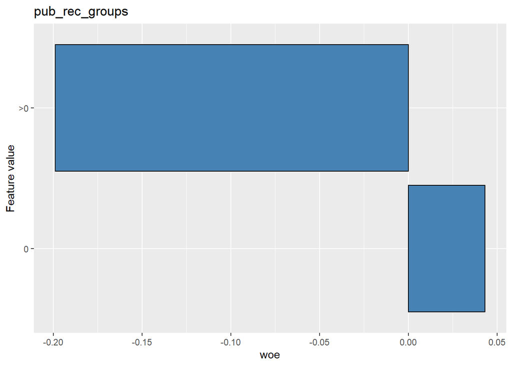

```r
adj_pub_rec <- function(x){
  if(x==0){
    return("0")
  } else {
    return(">0")
  }
}

train$pub_rec_groups = sapply(train$pub_rec, adj_pub_rec)

woedf <- woe('pub_rec_groups', train)
plotWoeNumeric('pub_rec_groups', woedf)
```

## Month differences between loan and cr line

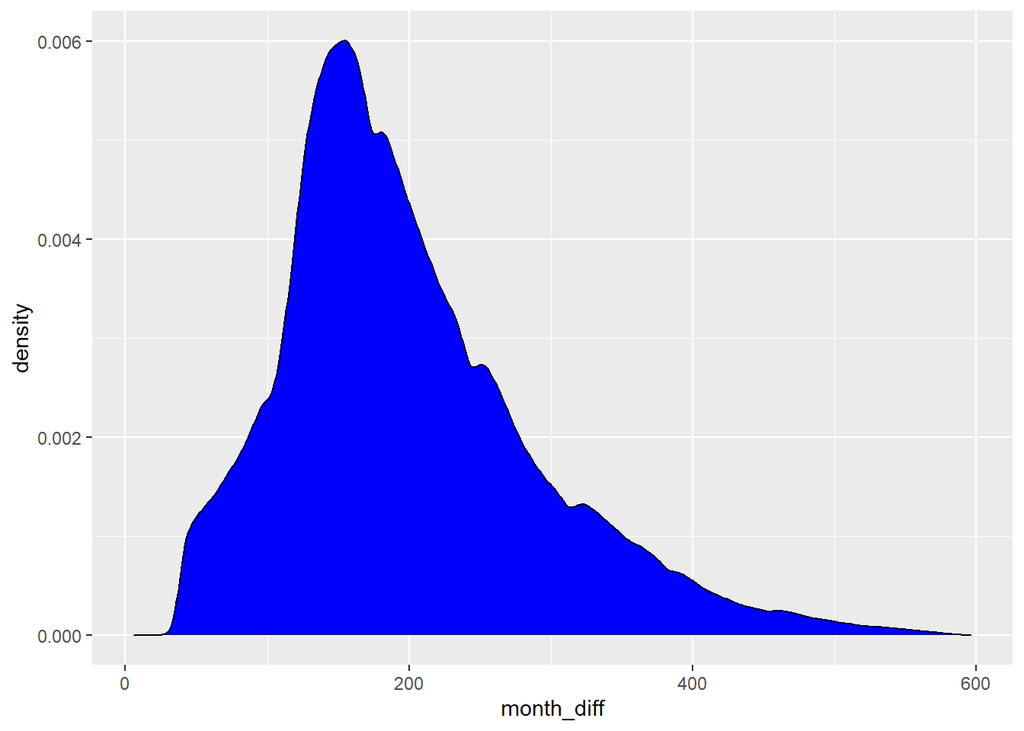

```r
# Ploting the distribution
ggplot(data=train, aes(x=month_diff)) + geom_density(fill='blue')
```

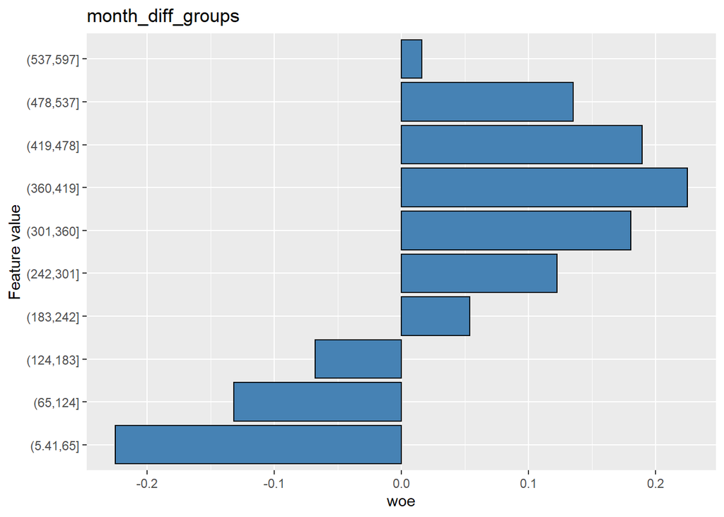

```r
# Cutting the annual income into 10 equal sized partitions
train$month_diff_groups = cut(train$month_diff , 10)

woedf <- woe('month_diff_groups', train)
plotWoeNumeric('month_diff_groups', woedf)
```

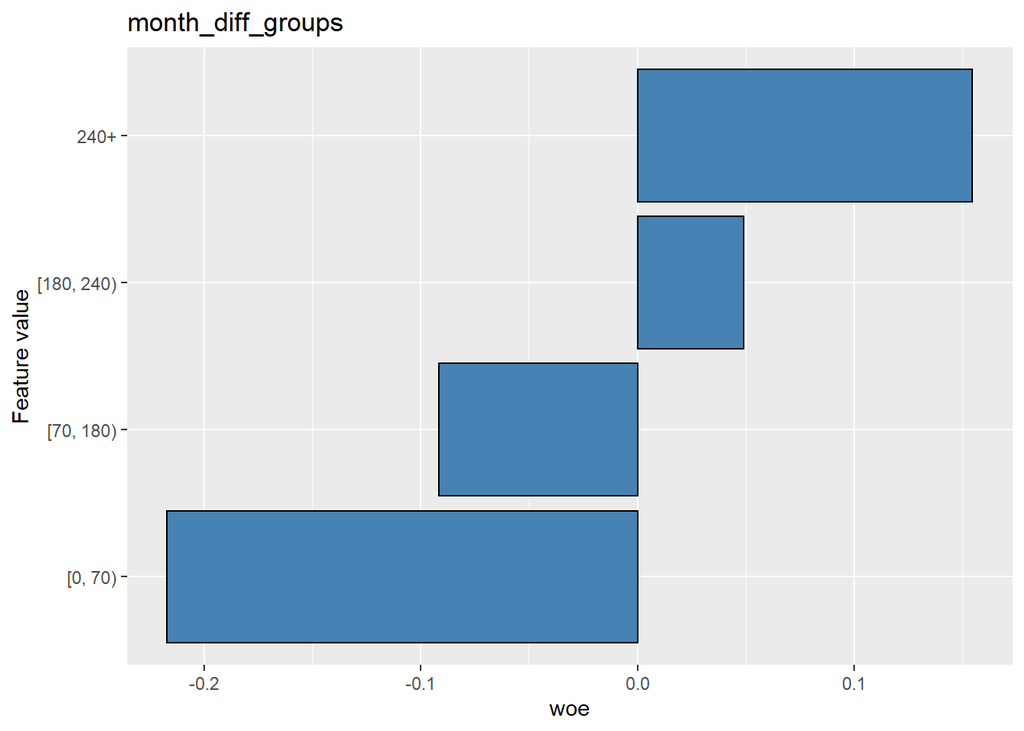

```r
adj_month_diff <- function(x){
  if(x<70){
    return("[0, 70)")
  } else if (x < 180){
    return("[70, 180)")
  } else if (x < 240) {
    return("[180, 240)")
  } else {
    return("240+")
  }
}

train$month_diff_groups = sapply(train$month_diff, adj_month_diff)

woedf <- woe('month_diff_groups', train)
plotWoe('month_diff_groups', woedf)
```

# Creating the final test and train frames

```r
# Subseting the data
train <- d[issue_d_formated < zoo::as.yearmon('2018-01')]
test <- d[issue_d_formated >= zoo::as.yearmon('2018-01')]

# Creating the Y variables for modeling
train$Ypd <- sapply(train$loan_status, create_Ypd)
test$Ypd <- sapply(test$loan_status, create_Ypd)

train[, recovery_rate:=recoveries/funded_amnt]
train[, recovery_rate:=ifelse(recovery_rate>1, 1, recovery_rate)]

test[, recovery_rate:=recoveries/funded_amnt]
test[, recovery_rate:=ifelse(recovery_rate>1, 1, recovery_rate)]

train[, CCF:=(funded_amnt - total_rec_prncp)/funded_amnt]
test[, CCF:=(funded_amnt - total_rec_prncp)/funded_amnt]

# Train set adjustmetns
train$pub_recg <- sapply(train$pub_rec, adj_pub_rec)
train$annual_incg <- sapply(train$annual_inc, adj_income)
train$dtig <- sapply(train$dti, adj_dti)
train$month_diffg <- sapply(train$month_diff, adj_month_diff)
train$emp_lengthg <- sapply(train$emp_length, adj_emp_length)
train$int_rateg <- sapply(train$int_rate, adj_int_rate)
train$loan_amntg <- sapply(train$loan_amnt, adj_loan_amnt)
train$addr_stateg <- sapply(train$addr_state, adj_addr_state)
train$purposeg <- sapply(train$purpose, adj_purpose)

# Test set adjustments
test$pub_recg <- sapply(test$pub_rec, adj_pub_rec)
test$annual_incg <- sapply(test$annual_inc, adj_income)
test$dtig <- sapply(test$dti, adj_dti)
test$month_diffg <- sapply(test$month_diff, adj_month_diff)
test$emp_lengthg <- sapply(test$emp_length, adj_emp_length)
test$int_rateg <- sapply(test$int_rate, adj_int_rate)
test$loan_amntg <- sapply(test$loan_amnt, adj_loan_amnt)
test$addr_stateg <- sapply(test$addr_state, adj_addr_state)
test$purposeg <- sapply(test$purpose, adj_purpose)

# Feature list for PD model
featuresToUse = c(
  "issue_d_formated",
  "loan_status",
  "Ypd",
  "funded_amnt",
  "recovery_rate",
  "CCF",
  "term",
  "pub_recg",
  'annual_inc',
  "annual_incg",
  'dti',
  "dtig",
  'month_diff',
  "month_diffg",
  'emp_length',
  "emp_lengthg",
  'int_rate',
  "int_rateg",
  'loan_amnt',
  "loan_amntg",
  'grade',
  "addr_stateg",
  'purpose',
  'purposeg'
)

featuresMLPD <- c(
  "term",
  "pub_recg",
  "annual_incg",
  "dtig",
  "month_diffg",
  "emp_lengthg",
  "int_rateg",
  "loan_amntg",
  'grade',
  "addr_stateg",
  "purposeg"
)

# Beta regression features
featuresMLbeta <- c(
  "term",
  "pub_recg",
  "annual_inc",
  "dti",
  "month_diff",
  #"emp_lengthg",
  "int_rate",
  "loan_amnt",
  "grade",
  "addr_stateg",
  "purposeg"
)

# Subsetting
train <- train[, ..featuresToUse]
test <- test[, ..featuresToUse]

# Saving the data for PD
write.csv(na.omit(train), 'data/train.csv', row.names=FALSE)
write.csv(na.omit(test), 'data/test.csv', row.names=FALSE)

# Creating frames for charged off loans
loan_default_data_train = train[loan_status %in% c("Charged Off", "Does not meet the credit policy. Status:Charged Off")]
loan_default_data_test = test[loan_status %in% c("Charged Off", "Does not meet the credit policy. Status:Charged Off")]

# Saving the data for PD
write.csv(na.omit(loan_default_data_train), 'data/train_defaults.csv', row.names=FALSE)
write.csv(na.omit(loan_default_data_test), 'data/test_defaults.csv', row.names=FALSE)

# Saving feature list
write.csv(featuresMLPD, "data/featuresMLPD.csv")
write.csv(featuresMLbeta, "data/featuresMLbeta.csv")
```